# Лабораторная работа №14

Настройка файловых служб Samba

Жукова Арина Александровна

1132239120@rudn.ru

Российский университет дружбы народов

2025-12-06

# Информация

## Докладчик

- Жукова Арина Александровна
- Студентка 3 курса
- Российский университет дружбы народов им. П. Лумумбы
- 1132239120@rudn.ru

# Вводная часть

## Актуальность

- Протокол SMB — стандарт для организации сетевого доступа к файлам и принтерам
- Необходим навык настройки совместного доступа между ОС Linux и другими системами
- Samba — ключевое решение для интеграции Unix/Linux-систем в сети Windows

## Объект и предмет исследования

- **Объект:** Файловый сервер Samba
- **Предмет:** Настройка общего доступа к ресурсам по протоколу SMB в изолированной виртуальной среде

## Цель работы

Приобретение практических навыков настройки доступа групп пользователей к общим сетевым ресурсам с использованием сервера Samba.

# Задание и метод выполнения

## Задачи работы

1. **Установить и настроить** сервер Samba на виртуальной машине `server`
2. **Настроить клиентский доступ** к общим ресурсам на машине `client`
3. **Автоматизировать** процесс развёртывания с помощью `Vagrant` и скриптов

## План выполнения (Метод)

- Ручная настройка сервера Samba и клиента для понимания процесса
- Проверка доступности ресурсов и прав доступа
- Настройка безопасности (firewalld, SELinux)
- Автоматизация через скрипты Bash и интеграция в `Vagrantfile`

# Ход работы

## Настройка сервера Samba (1)

- Установка необходимых пакетов
- Создание группы `sambagroup` (GID 1010) и добавление пользователя

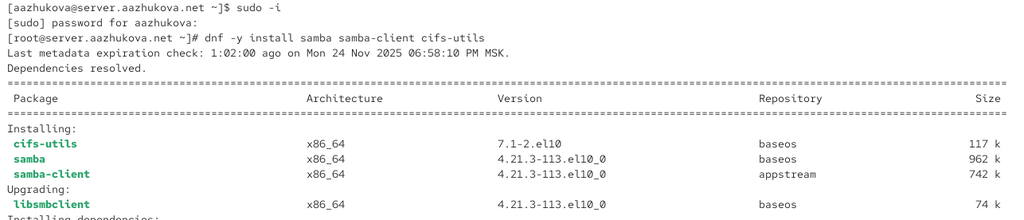

## Настройка сервера Samba (2)

- Создание общего каталога `/srv/sambashare`
- Конфигурация файла `/etc/samba/smb.conf`
- Проверка синтаксиса утилитой `testparm`

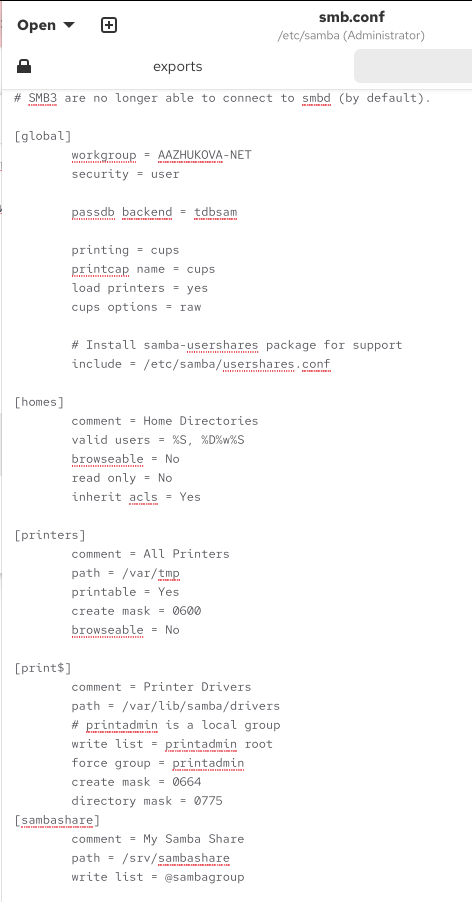

## Настройка безопасности

- Запуск и настройка службы `smb`
- Открытие портов в `firewalld`
- Настройка контекста безопасности SELinux для каталога

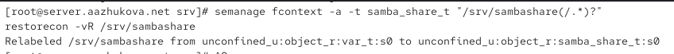

## Настройка клиента

- Установка клиентских пакетов (`samba-client`, `cifs-utils`)
- Настройка рабочей группы
- Проверка доступности ресурсов сервера

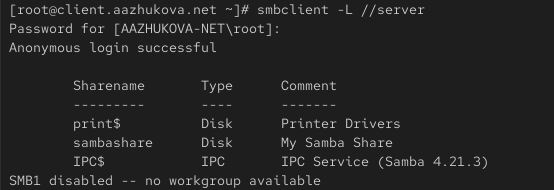

## Монтирование общего ресурса

- Создание точки монтирования `/mnt/samba`
- Ручное монтирование с аутентификацией
- Настройка автоматического монтирования через `/etc/fstab`

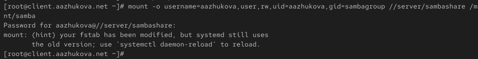

# Результаты

## Автоматизация настройки

- Созданы скрипты `smb.sh` для сервера и клиента
- Скрипты автоматически выполняют всю необходимую настройку
- Интеграция скриптов в `Vagrantfile

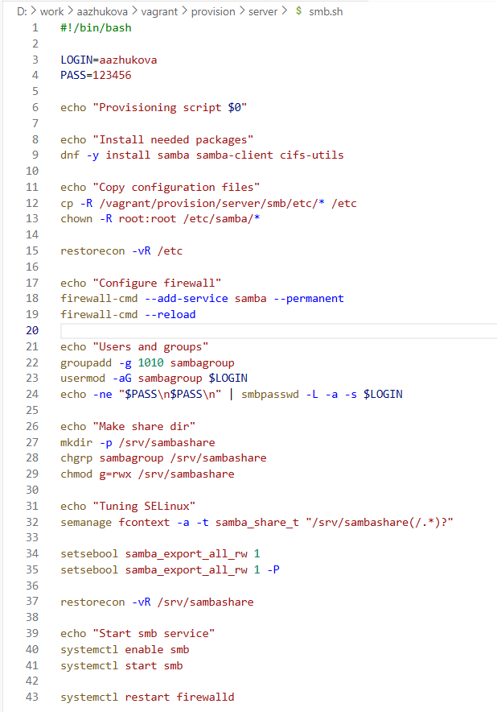

## Проверка работоспособности

- Успешный доступ к ресурсу `//server/sambashare` с клиента
- Возможность чтения и записи файлов под учётной записью пользователя
- Автоматическое монтирование ресурса при загрузке

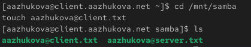

# Итоговый слайд

## Выводы

В ходе лабораторной работы **успешно**:

- Настроен сервер Samba с общим ресурсом
- Обеспечен безопасный доступ с учетом `firewalld` и `SELinux`
- Настроен клиентский доступ с ручным и автоматическим монтированием
- Процесс настройки **автоматизирован** с помощью `Vagrant` и скриптов

**Приобретены практические навыки** администрирования файловых служб в гетерогенной сети.